# Los Angeles Labor Market 1 Lab

Myron Bañez | CPLN 6200: Techniques of Urban Economic Development

# Introduction

This lab will be one of two labs looking at the labor market in Los Angeles County.

```r
knitr::opts_chunk$set(echo = TRUE)

options(scipen=999)
if(!require(pacman)){install.packages("pacman"); library(pacman)}
p_load(tidycensus, dplyr, ggplot2, hrbrthemes, here,janitor)

library(tidycensus)
library(sf)
library(tidyverse)
library(sf)
library(lubridate)
library(tigris)
library(gganimate)
library(riem)
library(gridExtra)
library(knitr)
library(kableExtra)
library(mapview)
library(tidycensus)
library(ggcorrplot)
library(RColorBrewer)
library(stargazer)
library(ggplot2)

emp_status <- get_acs(geography = "metropolitan statistical area/micropolitan statistical area",
                      year = 2020,
                      variables = c("White NH" = "S2301_C04_012",
                      "Black NH" = "S2301_C04_013",
                      "Amer. Indian NH" = "S2301_C04_014",
                      "Asian NH" = "S2301_C04_015",
                      "Native Hawaiian NH" = "S2301_C04_016",
                      "Other NH" = "S2301_C04_017",
                      "Two or more NH" = "S2301_C04_018",
                      "Hispanic/Latinx" = "S2301_C04_019"))

palette2 <- c("#6d597a","#e88c7d")
palette10 <- c("#283c55","#355070","#6d597a","#915f78","#b56576","#e56b6f","#e77c76","#e88c7d","#eaac8b","#eebba0")
```

# Unemployment by Race

## Data Wrangling

```r
emp_status_us <- get_acs(geography = "us",year = 2020,
                         variables = c("White NH" = "S2301_C04_012",
"Black NH" = "S2301_C04_013",
"Amer. Indian NH" = "S2301_C04_014",
"Asian NH" = "S2301_C04_015",
"Native Hawaiian NH" = "S2301_C04_016",
"Other NH" = "S2301_C04_017",
"Two or more NH" = "S2301_C04_018",
"Hispanic/Latinx" = "S2301_C04_019"))
```

The plot indicates that in the Los Angeles MSA, Black non-hispanic, two or more non-hispanic, and White non-hispanic groups experiencing higher unemployment rates when compared to the national level.

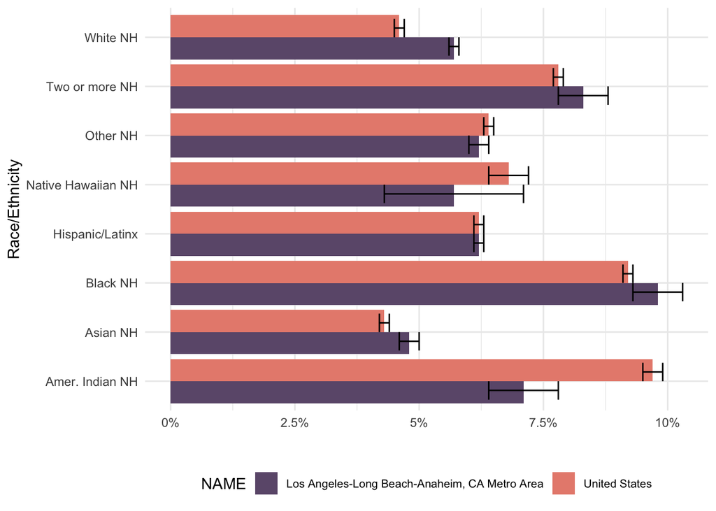

```r
la_emp <- emp_status %>%
  filter(GEOID == "31080") %>%
  bind_rows(emp_status_us) %>%
  mutate(NAME = stringr::str_remove(string = NAME,
                                    pattern = ", PA-NJ-DE-MD Metro Area"))

ggplot(la_emp, aes(variable, estimate, fill = NAME)) +
  geom_bar(stat = "identity", position = "dodge") +
  labs(x = "Race/Ethnicity", y = "") +

  scale_y_continuous(labels = function(x) paste0(x, "%")) +
  scale_fill_manual(values = palette2) +
  geom_errorbar(aes(ymin = estimate - moe, ymax = estimate + moe),
                width = .75, position = "dodge") +
  coord_flip() +
  theme_minimal() +
  theme(legend.position = "bottom", legend.text = element_text(size = 8))
```

# Class of Workers

## Data Wrangling

```r
worker_class <- get_acs(geography = "metropolitan statistical area/micropolitan statistical area",
variables = c("Total Emp." = "S2408_C01_001",
"Private, for-profit" = "S2408_C01_002",
"Private, not-for-profit" = "S2408_C01_005",
"Local Gov." = "S2408_C01_006",
"State Gov." = "S2408_C01_007",
"Federal" = "S2408_C01_008",
"Self Employed" = "S2408_C01_009"),
year = 2020)
```

```r
worker_class <- worker_class %>%
  filter(GEOID == "31080") %>%
  mutate(class_share = estimate/6501703)

worker_class_us <- get_acs(geography = "us",
                           variables = c("Total Emp." = "S2408_C01_001",
"Private, for-profit" = "S2408_C01_002",
"Private, not-for-profit" = "S2408_C01_005",
"Local Gov." = "S2408_C01_006",
"State Gov." = "S2408_C01_007",
"Federal" = "S2408_C01_008",
"Self Employed" = "S2408_C01_009"), year = 2020)
worker_class_us <- worker_class_us %>%
mutate(class_share = estimate/155888980)
```

Many workers at the MSA and national level work in the private, for profit class. The Los Angeles MSA specifically has a higher rate of self-employed and local government workers than the national rate.

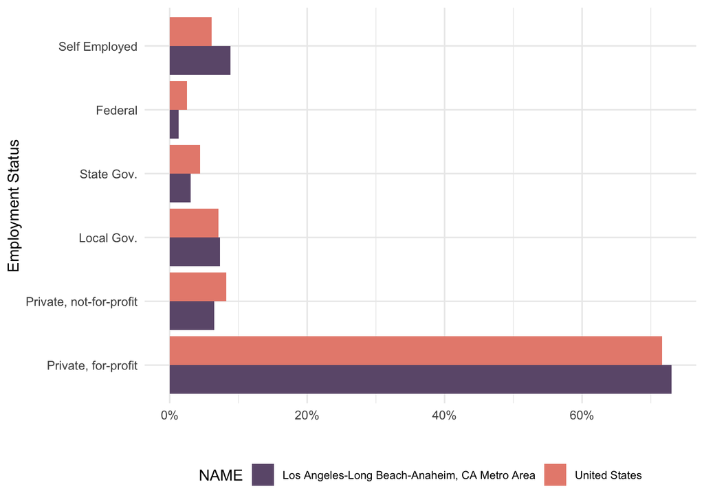

```r
worker_class_la <- worker_class %>%
  bind_rows(worker_class_us) %>%
  filter(variable != "Total Emp.")

worker_class_la <- worker_class_la %>%
  mutate(NAME = stringr::str_remove(string = NAME,
                                    pattern = ", PA-NJ-DE-MD Metro Area"))

worker_class_la <- worker_class_la %>%
  mutate(variable = factor(variable,
                           levels = c("Private, for-profit", "Private, not-for-profit", "Local Gov.",
                                      "State Gov.","Federal", "Self Employed")))

ggplot(worker_class_la, aes(variable, class_share, fill = NAME)) +
  geom_bar(stat = "identity", position = "dodge") +
  labs(x = "Employment Status", y = "") +
  scale_y_continuous(labels = scales::percent) +
  scale_fill_manual(values = palette2) +
  coord_flip() +
  theme_minimal() +
  theme(legend.position = "bottom",
  legend.text = element_text(size = 8))
```

# Extra

## Unemployment by Educational Attainment

In the Los Angeles MSA, people who identify as less than high school graduate and high school graduate are the predominant groups experiencing unemployment.

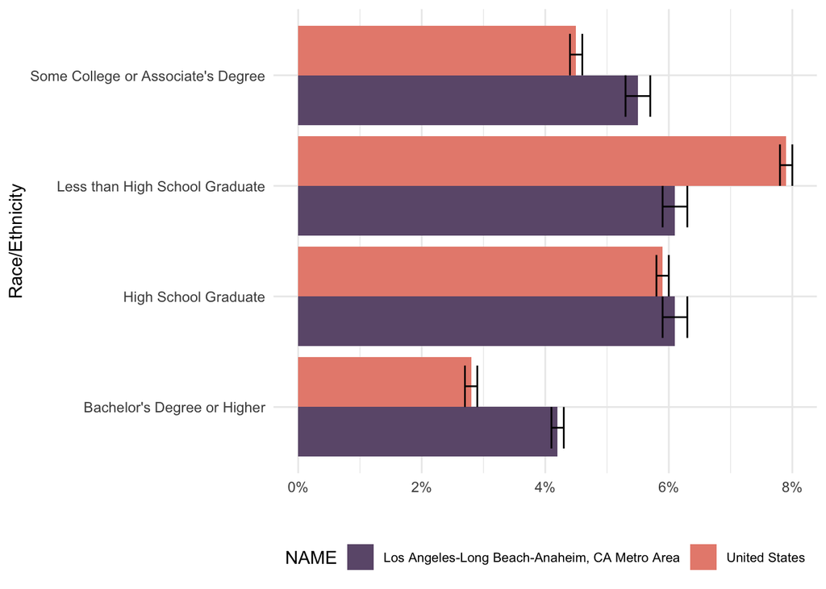

```r
ed_status <- get_acs(geography = "metropolitan statistical area/micropolitan statistical area",
                      year = 2020,
                     variables = c(
                       "Less than High School Graduate" = "S2301_C04_032",
                       "High School Graduate" = "S2301_C04_033",
                       "Some College or Associate's Degree" = "S2301_C04_034",
                       "Bachelor's Degree or Higher" = "S2301_C04_035"))

ed_status_us <- get_acs(geography = "us",year = 2020,
                         variables = c(
                       "Less than High School Graduate" = "S2301_C04_032",
                       "High School Graduate" = "S2301_C04_033",
                       "Some College or Associate's Degree" = "S2301_C04_034",
                       "Bachelor's Degree or Higher" = "S2301_C04_035"))

la_ed <- ed_status %>%
  filter(GEOID == "31080") %>%
  bind_rows(ed_status_us) %>%
  mutate(NAME = stringr::str_remove(string = NAME,
                                    pattern = ", PA-NJ-DE-MD Metro Area"))

ggplot(la_ed, aes(variable, estimate, fill = NAME)) +
  geom_bar(stat = "identity", position = "dodge") +
  labs(x = "Race/Ethnicity", y = "") +

  scale_y_continuous(labels = function(x) paste0(x, "%")) +
  scale_fill_manual(values = palette2) +
  geom_errorbar(aes(ymin = estimate - moe, ymax = estimate + moe),
                width = .75, position = "dodge") +
  coord_flip() +
  theme_minimal() +
  theme(legend.position = "bottom", legend.text = element_text(size = 8))
```

## Employment by Class (Government)

Combining the government classes, the group is still very minimal in compatison to the private, for-profit class.

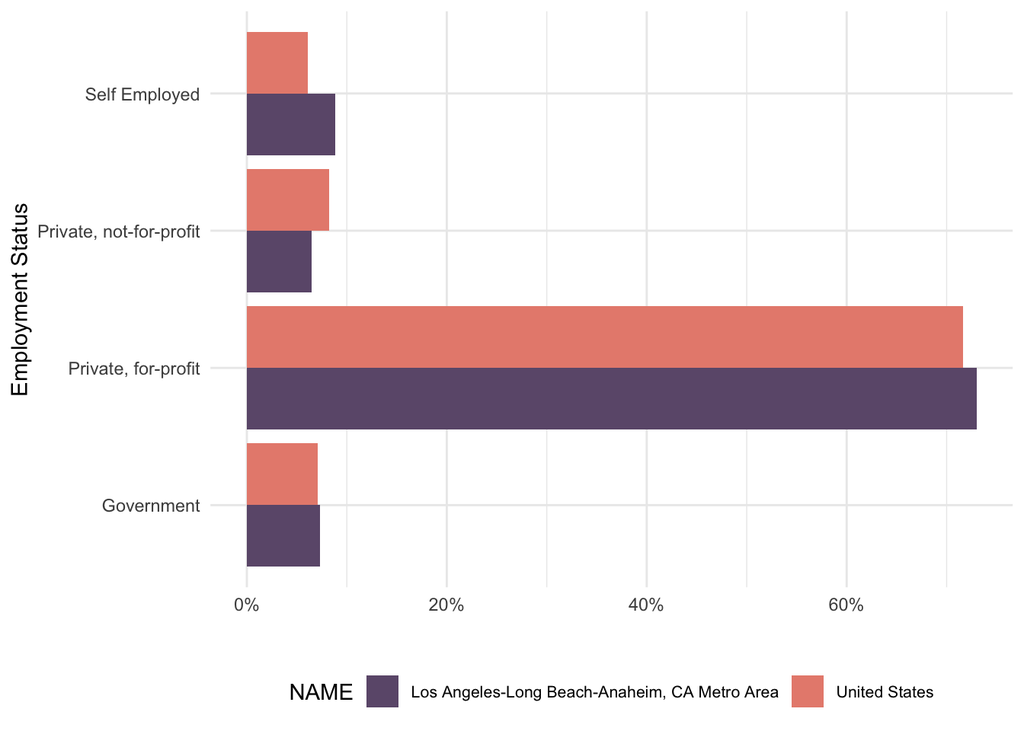

```r
worker_class_la <- worker_class_la %>%
  mutate(class = case_when(variable == "Local Gov." | variable == "State Gov." | variable == "Federal" ~ "Government",
                           variable == "Private, for-profit" ~ "Private, for-profit",
                           variable == "Private, not-for-profit" ~ "Private, not-for-profit",
                           variable == "Self Employed" ~ "Self Employed"))

ggplot(worker_class_la, aes(class, class_share, fill = NAME)) +
  geom_bar(stat = "identity", position = "dodge") +
  labs(x = "Employment Status", y = "") +
  scale_y_continuous(labels = scales::percent) +
  scale_fill_manual(values = palette2) +
  coord_flip() +
  theme_minimal() +
  theme(legend.position = "bottom",
  legend.text = element_text(size = 8))
```

## Top 10 Occupations in Los Angeles MSA

```r
oes <- read_csv("MSAOES.csv")
oes_nat <- read_csv("oes_nat.csv")

oes_data <- oes %>%
  inner_join(oes_nat, by = "Occupation (SOC code)",
  suffix = c("_msa", "_national"))

oes_data <- oes_data %>%
  rename(emp_msa = "Employment(1)_msa")

oes_data <- oes_data %>%
  rename(hour_mean_wage_msa = "Hourly mean wage_msa",
         ann_mean_wage_msa = "Annual mean wage(2)_msa",
         emp_national = "Employment(1)_national",
         hour_mean_wage_national = "Hourly mean wage_national",
         ann_mean_wage_national = "Annual mean wage(2)_national")

oes_data <- oes_data %>%
  rename(Occupation = "Occupation (SOC code)")

oes_data$emp_msa <- as.numeric(as.character(oes_data$emp_msa))
oes_data$hour_mean_wage_msa <- as.numeric(as.character(oes_data$hour_mean_wage_msa))
oes_data$ann_mean_wage_msa <- as.numeric(as.character(oes_data$ann_mean_wage_msa))
oes_data$hour_mean_wage_national <- as.numeric(as.character(oes_data$hour_mean_wage_national))
oes_data$ann_mean_wage_national <- as.numeric(as.character(oes_data$ann_mean_wage_national))

oes_data[is.na(oes_data)] = 0

oes_data <- oes_data %>%
  ungroup() %>%
  mutate(lq = (emp_msa/sum(emp_msa, na.rm = TRUE))/(emp_national/sum(emp_national,na.rm=TRUE)))

oes_data <- oes_data %>%
  ungroup() %>%
  mutate(hour_premium = (hour_mean_wage_msa/hour_mean_wage_national),
         ann_premium = (ann_mean_wage_msa/ann_mean_wage_national))

oes_data <- oes_data[!oes_data$Occupation == "All Occupations(000000)", ]
```

```r
oes_10 <- oes_data[order(oes_data$emp_msa,decreasing=T)[1:10],]

oes_10 %>%
  summarize(Occupation = Occupation,
            Employment = emp_msa,
            LQ = lq,
            Annual_Wage = ann_mean_wage_msa)%>%
    arrange(desc(Employment)) %>%
  kable(title = "Top 10 Occupations", caption = "Top 10 Occupations in Los Angeles MSA") %>%
  kable_styling("striped",full_width = F) %>%
  row_spec(1:5, background = '#6d597a') %>%
  row_spec(0, bold=TRUE) %>%
  column_spec(2:4, bold=TRUE)
```

Top 10 Occupations in Los Angeles MSA

| Occupation | Employment | LQ | Annual_Wage |
| --- | --- | --- | --- |
| Office and Administrative Support Occupations(430000) | 717630 | 0.9691271 | 48790 |
| Sales and Related Occupations(410000) | 510440 | 0.9515667 | 49940 |
| Transportation and Material Moving Occupations(530000) | 481620 | 0.9416223 | 43860 |
| Food Preparation and Serving Related Occupations(350000) | 448780 | 0.9900899 | 35430 |
| Healthcare Support Occupations(310000) | 421890 | 1.5788095 | 34390 |
| Management Occupations(110000) | 410750 | 1.1392546 | 135840 |
| Business and Financial Operations Occupations(130000) | 400550 | 1.0933088 | 86400 |
| Educational Instruction and Library Occupations(250000) | 329300 | 0.9933951 | 77020 |
| Healthcare Practitioners and Technical Occupations(290000) | 323700 | 0.9102958 | 108300 |
| Production Occupations(510000) | 302280 | 0.8884473 | 43380 |

The Cleveland Dot Plot provides another way to visualize the same data as seen above in a more simplistic way.

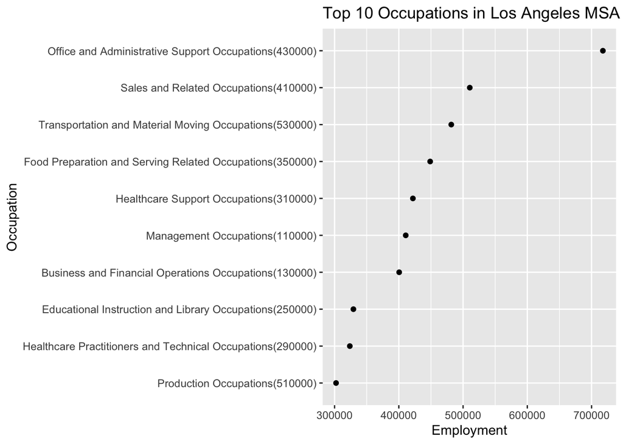

```r
ggplot(oes_10, aes(x = emp_msa, y = reorder(Occupation,emp_msa))) +
  geom_point() +
  labs(x = "Employment",
       y = "Occupation",
       title = "Top 10 Occupations in Los Angeles MSA")
```

```r
#oes2016 <- read_csv("MSA_2016.csv")
#oes2021 <- read_csv("MSA_2021.csv")

#soc_ref <- read_excel(("oes_2019_hybrid_structure.xlsx"), skip = 5) %>%
#  janitor::clean_names("snake")

#oes2016 <- oes2016 %>%
#  select(AREA, AREA_NAME, OCC_CODE, OCC_TITLE, TOT_EMP, H_MEAN, A_MEAN)

#oes2021 <- oes2021 %>%
 # select(AREA, AREA_NAME, OCC_CODE, OCC_TITLE, TOT_EMP, H_MEAN, A_MEAN)

#oes2016 <- oes2016 %>%
 # left_join(soc_ref, by = c("OCC_CODE" = "x2010_soc_code"))

#oes2016_2021 <- oes2016 %>%
  #left_join(oes2021, by = c("OCC_CODE" = "OCC_CODE"))


#oes2016_2021$TOT_EMP.x <- as.numeric(as.character(oes2016_2021$TOT_EMP.x))
#oes2016_2021$TOT_EMP.y <- as.numeric(as.character(oes2016_2021$TOT_EMP.y))

#oes2016_2021 <- oes2016_2021 %>%
 # mutate(change = )
```